# Lecture 1: Basic Models in Matrix Algebra

ETB

3/29/2022

## ANOVA in R: model specification

Here is a basic model with *y* as the dependent measure and *X1* as the independent variable (dummy coded).

```r
# y is the name of the DV (by convention)
y = c(1:10)

# X is the design matrix. In this case, an ANOVA/t-test with 2 or 3 groups
X = matrix(c(rep(1,5), rep(0,10), rep(1,5)), ncol=2)  # Two groups
# X = matrix(c(rep(1,10), c(17, 15, 13, 11, 9, 7, 5, 3, 1,-3)), ncol=2)
#X1 = matrix(c(rep(1,3), rep(0,10), rep(1,3), rep(0,10), rep(1,4)), ncol=3, byrow=F) # Three groups

X
```

```
##       [,1] [,2]
##  [1,]    1    0
##  [2,]    1    0
##  [3,]    1    0
##  [4,]    1    0
##  [5,]    1    0
##  [6,]    0    1
##  [7,]    0    1
##  [8,]    0    1
##  [9,]    0    1
## [10,]    0    1
```

## ANOVA in R: model estimation

Once the model is specified as above, we have all the pieces of our $Y = Xb+e$ equation except for $b$. So we need to solve for that. We do so by:

1. Assuming $e$ is, on average, equal to 0. (This is a fundamental assumption of the GLM)
2. Solve for $b$ by dividing both sides by $X$.
3. (Division is the same as multiplying by the inverse.)

```r
# Inverse of X (actually the 'generalized' or pseudoinverse)
invx = ginv(X)

# Solve for beta using: beta = X^(-1) * y
beta = ginv(X) %*% y
beta
```

```
##      [,1]
## [1,]    3
## [2,]    8
```

```r
# The model part of the GLM equation (Y = Xb + e), Xb
model = X %*% beta
model
```

```
##       [,1]
##  [1,]    3
##  [2,]    3
##  [3,]    3
##  [4,]    3
##  [5,]    3
##  [6,]    8
##  [7,]    8
##  [8,]    8
##  [9,]    8
## [10,]    8
```

```r
# The error part of the GLM equation (Y = Xb + e), e
e = y - model
e
```

```
##                [,1]
##  [1,] -2.000000e+00
##  [2,] -1.000000e+00
##  [3,]  8.881784e-16
##  [4,]  1.000000e+00
##  [5,]  2.000000e+00
##  [6,] -2.000000e+00
##  [7,] -1.000000e+00
##  [8,]  8.881784e-16
##  [9,]  1.000000e+00
## [10,]  2.000000e+00
```

## ANOVA in R: statistical tests

Now that we have all the pieces, we can use them to calculate a signal to noise ratio: variance explained by the model divided by variance left over.

```r
# Sum-of-squares error = e'e, or "t(e)" times e
ss_e = t(e) %*% e
ss_e
```

```
##      [,1]
## [1,]   20
```

```r
# Sum-of-squares model = model'model, after subtracting the mean of the DV
ss_m = t(model-mean(y)) %*% (model-mean(y))
ss_m
```

```
##      [,1]
## [1,] 62.5
```

```r
# Degrees-of-freedom error is the number of rows - number of columns (r-c) of the design matrix
df_e = dim(X)[1] - dim(X)[2]  # the "size" function of a matrix wants the matrix (X) and row (1) or column (2)
df_e
```

```
## [1] 8
```

```r
# Degrees-of-freedom model is the number of columns in X (equivalent to # of rows in the betas) minus 1
df_m = dim(X)[2] - 1
df_m
```

```
## [1] 1
```

```r
# Mean-squared error = sum-of-squares error divided by degrees-of-freedom error
ms_e = ss_e / df_e
ms_e
```

```
##      [,1]
## [1,]  2.5
```

```r
# Mean-squared model = sum-of-squares model divided by degrees-of-freedom model
ms_m = ss_m / df_m
ms_m
```

```
##      [,1]
## [1,] 62.5
```

```r
# F is a signal-to-noise ratio where signal = mean-squared model and noise = mean-squared error
F = ms_m / ms_e
F
```

```
##      [,1]
## [1,]   25
```

```r
# p-value is the probability of obtainining an F-value of "F" or greater from a F-distribution
# arguments are f, df_m, df_e, and whether to take the P(F>f) [lower.tail=FALSE] or P(F<f) [lower.tail=TRUE]
pval = pf(F, df_m, df_e, lower.tail = FALSE)
pval
```

```
##             [,1]
## [1,] 0.001052826
```

```r
# Now compare with your by-hand or R calculations
```

The easy way:

```r
group = c(rep(1,5), rep(2,5))
easy_way = lm(y ~ factor(group))
# easy_way = lm(y~c(17, 15, 13, 11, 9, 7, 5, 3, 1,-3))

summary(easy_way)
```

```
##
## Call:
## lm(formula = y ~ factor(group))
##
## Residuals:
##    Min     1Q Median     3Q    Max
##     -2     -1      0      1      2
##
## Coefficients:
##                Estimate Std. Error t value Pr(>|t|)
## (Intercept)      3.0000     0.7071   4.243  0.00283 **
## factor(group)2   5.0000     1.0000   5.000  0.00105 **
## ---
## Signif. codes:  0 '***' 0.001 '**' 0.01 '*' 0.05 '.' 0.1 ' ' 1
##
## Residual standard error: 1.581 on 8 degrees of freedom
## Multiple R-squared:  0.7576, Adjusted R-squared:  0.7273
## F-statistic:    25 on 1 and 8 DF,  p-value: 0.001053
```

```r
# Is a t-test the same as an F-test? Compare and contrast
# HINT: square the t-value...
t.test(y~group)
```

```
##
##  Welch Two Sample t-test
##
## data:  y by group
## t = -5, df = 8, p-value = 0.001053
## alternative hypothesis: true difference in means is not equal to 0
## 95 percent confidence interval:
##  -7.306004 -2.693996
## sample estimates:
## mean in group 1 mean in group 2
##               3               8
```

## What if we wanted to do regression?

Regression is *exactly the same*, as long as you change your design matrix accordingly. Note the inclusion of a column of all “1”s representing the *intercept*. The second column represents the predictor. (This makes sense because regressions with one predictor have two parameters.)

```r
# Regression
pred = c(17, 15, 13, 11, 9, 7, 5, 3, 1,-3)  # Likert-style continuous predictor (e.g., neuroticism)
X = matrix(c(rep(1,10), pred), byrow=0, ncol=2)  # Regression design matrix: column of 1s (for intercept), predictor
X
```

```
##       [,1] [,2]
##  [1,]    1   17
##  [2,]    1   15
##  [3,]    1   13
##  [4,]    1   11
##  [5,]    1    9
##  [6,]    1    7
##  [7,]    1    5
##  [8,]    1    3
##  [9,]    1    1
## [10,]    1   -3
```

## Regression in R: estimation and stats

Now you can re-run the *exact same code* as above to estimate the model and conduct the tests. Yup. The solution code (inverting X, multiplying both sides by the inverse of $X$, calculating $e$, the $df$, the stats, etc) are all the same.

```r
invx = ginv(X)

# Solve for beta using: beta = X^(-1) * y
beta = ginv(X) %*% y

# The model part of the GLM equation (Y = Xb + e), Xb
model = X %*% beta

# The error part of the GLM equation (Y = Xb + e), e
e = y - model

# Sum-of-squares error = e'e, or "t(e)" times e
ss_e = t(e) %*% e

# Sum-of-squares model = model'model, after subtracting the mean of the DV
ss_m = t(model-mean(y)) %*% (model-mean(y))

# Degrees-of-freedom error is the number of rows - number of columns (r-c) of the design matrix
df_e = dim(X)[1] - dim(X)[2]  # the "size" function of a matrix wants the matrix (X) and row (1) or column (2)

# Degrees-of-freedom model is the number of columns in X (equivalent to # of rows in the betas) minus 1
df_m = dim(X)[2] - 1

# Mean-squared error = sum-of-squares error divided by degrees-of-freedom error
ms_e = ss_e / df_e

# Mean-squared model = sum-of-squares model divided by degrees-of-freedom model
ms_m = ss_m / df_m

# F is a signal-to-noise ratio where signal = mean-squared model and noise = mean-squared error
F = ms_m / ms_e
F
```

```
##          [,1]
## [1,] 1121.333
```

```r
# p-value is the probability of obtainining an F-value of "F" or greater from a F-distribution
# arguments are f, df_m, df_e, and whether to take the P(F>f) [lower.tail=FALSE] or P(F<f) [lower.tail=TRUE]
pval = pf(F, df_m, df_e, lower.tail = FALSE)
pval
```

```
##              [,1]
## [1,] 6.905001e-10
```

## Plot the regression results

You can plot the regression results thusly:

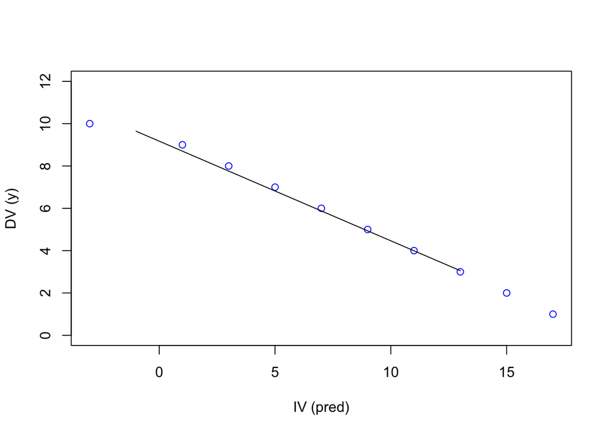

```r
xrange = c(-1:13)
plot(pred, y, col="blue", ylim=c(0,12), ylab = "DV (y)", xlab="IV (pred)")
lines(xrange, beta[1] + beta[2]*xrange)
```